### Part II

#### Solution

Tuesday, May 19, 2015

**5.** A survey was administered in a split-level introductory Statistics class (a course with both Statistics 3502 and Statistics 6304 students in the class at the same time) to determine if, upon entry to the class, the students had used MS EXCEL before, and if so, had they ever computed a Pivot Table using the software.

The survey was administered to the split-level class and the data was entered into an MS EXCEL spreadsheet. (See the file `Survey_nonames_nocountry.xlsx`)

The main question to be answered by the survey was, of the students who have used MS EXCEL before, is there a difference between the percentages of students, in STAT 3502 and STAT 6304, who had computed a Pivot Table?

1. Begin by cleaning the data. Examine the variables **Level** and **Class** to make sure that the categories for these variables were correctly entered. Which variable had data entry mistakes? What were the mistakes?  
   **Solution**  
   Copy from Excel and paste:

```r
raw.text <- "
Major   Level   Class   Excel   Pivot   Distance
Computer Science    Grad    3502    Yes No  10
Engineering Management  Grad    3502    Yes No  0.3
Biochemistry    Junior  3502    Yes No  1
Engineering Management  Grad    3502    Yes No  0.5
Computer Science    Junior  3502    Yes No  10
Compuer Science Grad    3502    Yes No  0.5
Engineering Management  Grad    3502    Yes No  15
Engineering Management  Grad    3502    Yes No  39
Engineering Management  Grad    3502    Yes No  25
Computer Science    Junior  3502    Yes Yes 28
Computer Science    Senior  3502    Yes     2.5
Biochemistry    Junior  3502    Yes No  2
Statistics  Spohmore    3502    No
Open University Open University 3502    Yes No  7
Mathematics Grad    6304    Yes No  35
Biostatistics   Grad    6304    Yes No  25
Biostatistics   Grad    6304    Yes No  1
Computer Science    Senior  3502    Yes No  5.5
Computer Science    Junior  3502    Yes No  34
Computer Science    Senior  3502    Yes Yes 5
Statistics  Grad    6304    Yes Yes 66
Computer Science    Junior  3502    Yes No  7
Computer Science    Junior  3502    Yes No  17
Engineering Management  Grad    3502    No      1
Computer Science    Junior  3502    No      2
Statistics  Grad    6304    Yes No  2
Computer Science    Junior  3502    Yes No  23
Statistics  Grad    6304    Yes Yes 10
Computer Science    Junior  3502    No      25
Computer Science    Junior  3502    Yes No  32
Statistics  Grad    6304    Yes Yes 5.1
Statistics  Grad    6304    Yes No  25
Statistics  Sophomore   3502    Yes No  1.5
Computer Science    Sophmore    3502    Yes No  17
Engineering Management  Grad    3502    Yes No  13
Mathematics Grad    3502    Yes No  35
Computer Science    Senior  3502    Yes No  5
"

#Standard `read.table()` will run into an error.
#Examine raw text
raw.text
```

```
## [1] "\nMajor\tLevel\tClass\tExcel\tPivot\tDistance\nComputer Science\tGrad\t3502\tYes\tNo\t10\nEngineering Management\tGrad\t3502\tYes\tNo\t0.3\nBiochemistry\tJunior\t3502\tYes\tNo\t1\nEngineering Management\tGrad\t3502\tYes\tNo\t0.5\nComputer Science\tJunior\t3502\tYes\tNo\t10\nCompuer Science\t…
```

```r
#Cells are tab-separated
survey.draft <- read.table(header=TRUE, sep="\t", text=raw.text)
```

Now examine the data.

```r
str(survey.draft)
```

```
## 'data.frame':    37 obs. of  6 variables:
##  $ Major   : Factor w/ 8 levels "Biochemistry",..: 4 5 1 5 4 3 5 5 5 4 ...
##  $ Level   : Factor w/ 7 levels "Grad","Junior",..: 1 1 2 1 2 1 1 1 1 2 ...
##  $ Class   : int  3502 3502 3502 3502 3502 3502 3502 3502 3502 3502 ...
##  $ Excel   : Factor w/ 2 levels "No","Yes": 2 2 2 2 2 2 2 2 2 2 ...
##  $ Pivot   : Factor w/ 3 levels "","No","Yes": 2 2 2 2 2 2 2 2 2 3 ...
##  $ Distance: num  10 0.3 1 0.5 10 0.5 15 39 25 28 ...
```

```r
survey.draft
```

```
##                     Major           Level Class Excel Pivot Distance
## 1        Computer Science            Grad  3502   Yes    No     10.0
## 2  Engineering Management            Grad  3502   Yes    No      0.3
## 3            Biochemistry          Junior  3502   Yes    No      1.0
## 4  Engineering Management            Grad  3502   Yes    No      0.5
## 5        Computer Science          Junior  3502   Yes    No     10.0
## 6         Compuer Science            Grad  3502   Yes    No      0.5
## 7  Engineering Management            Grad  3502   Yes    No     15.0
## 8  Engineering Management            Grad  3502   Yes    No     39.0
## 9  Engineering Management            Grad  3502   Yes    No     25.0
## 10       Computer Science          Junior  3502   Yes   Yes     28.0
## 11       Computer Science          Senior  3502   Yes            2.5
## 12           Biochemistry          Junior  3502   Yes    No      2.0
## 13             Statistics        Spohmore  3502    No             NA
## 14        Open University Open University  3502   Yes    No      7.0
```

[output cut: 23 more lines]

See what the unique entries for each column of data:

```r
apply(X=survey.draft,
      MARGIN=2, # 1 applies operation on rows, 2 on columns
      FUN=unique)
```

```
## $Major
## [1] "Computer Science"       "Engineering Management"
## [3] "Biochemistry"           "Compuer Science"
## [5] "Statistics"             "Open University"
## [7] "Mathematics"            "Biostatistics"
##
## $Level
## [1] "Grad"            "Junior"          "Senior"          "Spohmore"
## [5] "Open University" "Sophomore"       "Sophmore"
##
## $Class
## [1] "3502" "6304"
##
## $Excel
## [1] "Yes" "No"
##
## $Pivot
## [1] "No"  "Yes" ""
##
## $Distance
##  [1] "10.0" " 0.3" " 1.0" " 0.5" "15.0" "39.0" "25.0" "28.0" " 2.5" " 2.0"
## [11] NA     " 7.0" "35.0" " 5.5" "34.0" " 5.0" "66.0" "17.0" "23.0" "32.0"
## [21] " 5.1" " 1.5" "13.0"
```

There are empty cells in the “Pivot” and “Distance” columns. Also, there are typos: “Computer Science” and “Sophomore” are misspelled.

For the rest of the problem use the cleaned spreadsheet `Survey_nonames_nocountry_corrected.xlsx`

2. How many students in the class of 47 students participated in the survey? How many students were in STAT 3502? How many were in STAT 6304?  
   **Solution**  
   Copy corrected file from Excel and paste:

```r
raw.text <- "
Major   Level   Class   Excel   Pivot   Distance
Computer Science    Grad    3502    Yes No  10
Engineering Management  Grad    3502    Yes No  0.3
Biochemistry    Junior  3502    Yes No  1
Engineering Management  Grad    3502    Yes No  0.5
Computer Science    Junior  3502    Yes No  10
Compuer Science Grad    3502    Yes No  0.5
Engineering Management  Grad    3502    Yes No  15
Engineering Management  Grad    3502    Yes No  39
Engineering Management  Grad    3502    Yes No  25
Computer Science    Junior  3502    Yes Yes 28
Computer Science    Senior  3502    Yes     2.5
Biochemistry    Junior  3502    Yes No  2
Statistics  Sophmore    3502    No
Open University Open University 3502    Yes No  7
Mathematics Grad    6304    Yes No  35
Biostatistics   Grad    6304    Yes No  25
Biostatistics   Grad    6304    Yes No  1
Computer Science    Senior  3502    Yes No  5.5
Computer Science    Junior  3502    Yes No  34
Computer Science    Senior  3502    Yes Yes 5
Statistics  Grad    6304    Yes Yes 66
Computer Science    Junior  3502    Yes No  7
Computer Science    Junior  3502    Yes No  17
Engineering Management  Grad    3502    No      1
Computer Science    Junior  3502    No      2
Statistics  Grad    6304    Yes No  2
Computer Science    Junior  3502    Yes No  23
Statistics  Grad    6304    Yes Yes 10
Computer Science    Junior  3502    No      25
Computer Science    Junior  3502    Yes No  32
Statistics  Grad    6304    Yes Yes 5.1
Statistics  Grad    6304    Yes No  25
Statistics  Sophmore    3502    Yes No  1.5
Computer Science    Sophmore    3502    Yes No  17
Engineering Management  Grad    3502    Yes No  13
Mathematics Grad    3502    Yes No  35
Computer Science    Senior  3502    Yes No  5
"
survey.df <- read.table(header=TRUE, sep="\t", text=raw.text)
```

Number of people who participated:

```r
nrow(survey.df)
```

```
## [1] 37
```

Number of students in STAT 3502 and STAT 6304:

```r
sum(survey.df$Class == 3502)
```

```
## [1] 29
```

```r
sum(survey.df$Class == 6304)
```

```
## [1] 8
```

3. Make a table cross-classifying the variables **Class** and **Pivot**, where the rows are the categories from the **Class** variable and columns are the categories from the **Pivot** variable. In the cells of the table include the counts and *overall* percentages.  
   **Solution**

```r
# Blank entries are not to be included in the statistics.
# Must turn blank entries into NA values
survey.df$PivotNA <- survey.df$Pivot
survey.df$PivotNA[survey.df$PivotNA == ""] <- NA

cross.table <- table(survey.df$Class, # rows
                     survey.df$PivotNA, # columns
                     useNA="no")
cross.table
```

```
##
##           No Yes
##   3502  0 22   2
##   6304  0  5   3
```

```r
prop.table(cross.table)
```

```
##
##                     No     Yes
##   3502 0.00000 0.68750 0.06250
##   6304 0.00000 0.15625 0.09375
```

4. Make a table cross-classifying the variables **Class** and **Pivot**, where the rows are the categories from the **Class** variable and columns are the categories from the **Pivot** variable. In the cells of the table include the counts and the *row* percentages.  
   **Solution**

```r
prop.table(x=cross.table,
           margin=1) # row percentages
```

```
##
##                           No        Yes
##   3502 0.00000000 0.91666667 0.08333333
##   6304 0.00000000 0.62500000 0.37500000
```

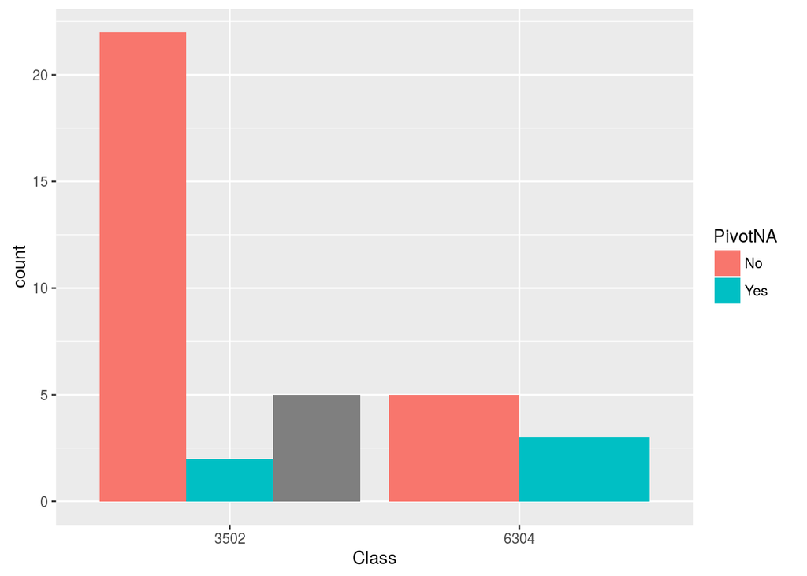

```r
# convert class number from integer into factor
survey.df$Class <- factor(survey.df$Class)

library(ggplot2)
ggplot(data=survey.df, # remove NA values
       mapping=aes(x=Class, fill=PivotNA)) + geom_bar(position="dodge")
```

8. Perform a statistical test to compare the proportion of students in each class who have created a Pivot table before? Explain the assumptions of the test you run and explain any violations in the assumptions of the test.  
   **Solution**  
   A statistical test for the difference between two population proportions:  
   $H_0: \pi_{6304} = \pi_{3502}$  
   $H_a: \pi_{6304} \neq \pi_{3502}$  
   T.S.: $z^*=\frac{\hat{\pi}_{6304} - \hat{\pi}_{3502}}{\sqrt{\frac{\hat{\pi}_{6304}(1 - \hat{\pi}_{6304})}{n_{6304}} + \frac{\hat{\pi}_{3502}(1 - \hat{\pi}_{3502})}{n_{3502}}}}$ Rejection Region: $|z^*| > z_{\alpha/2}$

To use `prop.test()`, either enter in a matrix of successes and failures:

```r
#consider prop.test(), t.test(), chisq.test()
success.matrix <- cbind(success=cross.table[,3], failure=cross.table[,2])
success.matrix
```

```
##      success failure
## 3502       2      22
## 6304       3       5
```

```r
prop.test(x=success.matrix)
```

```
##
##  2-sample test for equality of proportions with continuity
##  correction
##
## data:  success.matrix
## X-squared = 1.9753, df = 1, p-value = 0.1599
## alternative hypothesis: two.sided
## 95 percent confidence interval:
##  -0.7282274  0.1448941
## sample estimates:
##     prop 1     prop 2
## 0.08333333 0.37500000
```

Or enter in the first parameter a vector of successes and in the second parameter a vector of respective trials (not failures):

```r
prop.test(x=c(2, 3), n=c(24, 8))
```

[output not shown]

The default parameter is that test is two sided with $\alpha=0.05$.

Unfortunately, one of the conditions is that each cell must be at least 5. So this test is invalid.

An alternative would be to apply Fisher’s exact test:

```r
fisher.test(x=success.matrix)
```

```
##
##  Fisher's Exact Test for Count Data
##
## data:  success.matrix
## p-value = 0.08537
## alternative hypothesis: true odds ratio is not equal to 1
## 95 percent confidence interval:
##  0.01085891 1.81808468
## sample estimates:
## odds ratio
##  0.1639088
```

*p*-value $=0.085$, which means that we fail to reject the null hypothesis.